# Lab 4 - BINF 6310

Erin Tsai

### Problem 1

##### 1A) Plot the prior graph for a situation for a coin where the prior belief for p(head) is represented by the following R code:

- dexp(x, rate = 5) / 0.9932621

##### For values of 0 <= x <= 1 and 0 otherwise. (We choose the denominator to make the integral between 0 and 1 sum to 1).

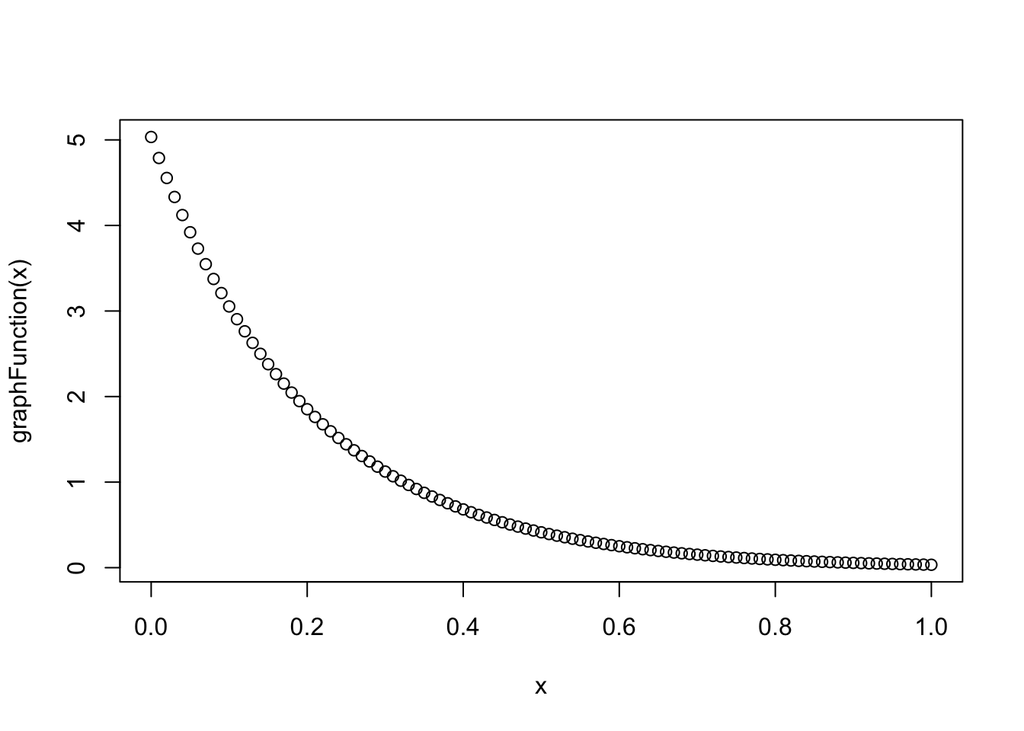

```r
x = seq(0, 1, 0.01)
graphFunction = function(x) (dexp(x, rate = 5)/0.9932621)
plot(x, graphFunction(x))
```

##### 1B) Calculate the posterior graph with both the Metropolis algorithm and grid approximation for a case with 14 heads and 10 tails (where x = prob(head)). Show the two methods roughly agree. Compare these to a plot with a posterior for new data of 14 heads and 10 tails with a prior with beta(40,40).

###### (So for the observation of 14 heads and 10 tails you will end up with a graph with three plots superimposed: (i) the Metropolis algorithm with an exp prior, (ii) grid approximation with an exp prior and (iii) exact analytical solution from a beta(40,40) prior make the plots different colors so you can visualize them…)

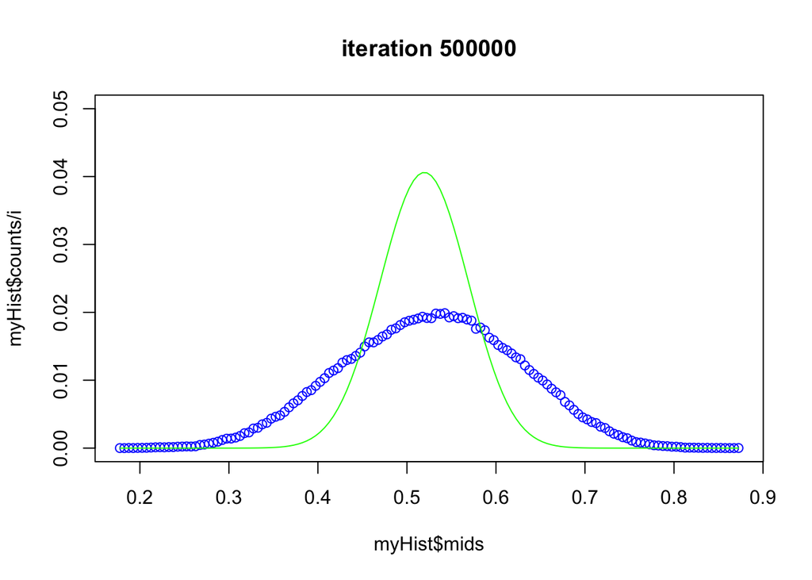

```r
numIterations = 500000

#metro calulations and plot
piOld = 0.5
posteriorDistribution = vector()

for(i in 1:numIterations){
  pOld = dbinom(14, 24, piOld) * (dexp(piOld, rate = 5)/0.9932621)
  piNew = piOld + rnorm(1, 0, sd = 0.01)

  if(piNew > 1){
    piNew = 1
  }

  if(piNew < 0){
    piNew = 0
  }

  pNew = dbinom(14, 24, piNew) * (dexp(piNew, rate = 5)/0.9932621)

  ratio = pNew/pOld

  if(ratio > 1 || ratio >= runif(1)){
    piOld = piNew
  }

  posteriorDistribution[i] = piOld
}

myHist = hist(posteriorDistribution, breaks = 200, plot = FALSE)
plot(myHist$mids, myHist$counts/i, ylim = c(0,0.05),main = paste("iteration", i), col = "blue")

#grid calculation
numBreaks = 1000
posteriorDistributionGrid = vector(length = numBreaks)
xVals = seq(0,1,1/numBreaks)
i = 1
sum = 0

for(x in xVals){
  posteriorDistributionGrid[i] = (dexp(x, rate = 5)/0.9932621) * dbinom(14, 24, x)
  sum = sum + posteriorDistributionGrid[i]
  i = i + 1
}

#beta plot with metro
dbetasum = sum(dbeta(myHist$mids, 40+10, 40+14))
lines(myHist$mids, dbeta(myHist$mids, 40+14, 40+10)/dbetasum, col="green")
```

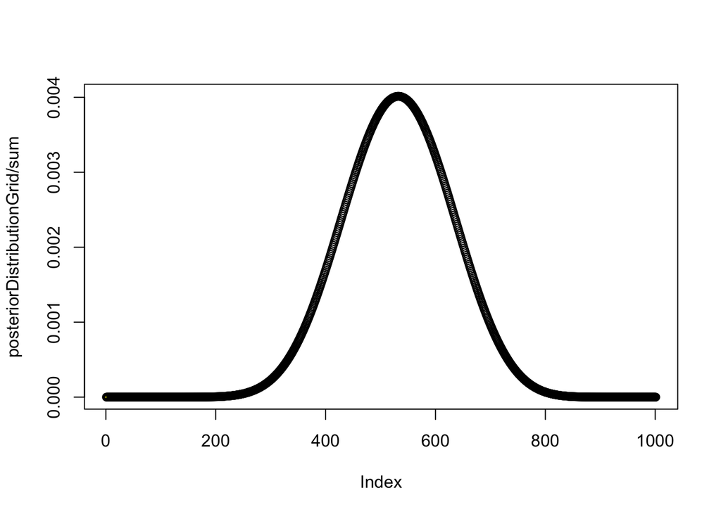

```r
#grid plot
plot(posteriorDistributionGrid/sum)
my_gridHist = hist(posteriorDistributionGrid, breaks = 200, plot = FALSE)
lines(my_gridHist$mids, dbeta(my_gridHist$mids, 40+14, 40+10)/dbetasum, col = "yellow")
```

##### 1C) Repeat the above calculation, but for a case of 583 heads and 417 tails. (You may need to adjust your model step parameters to try and get the grid and Metropolis graphs to match up).

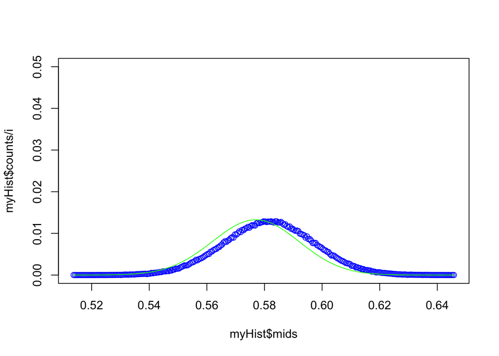

```r
numIterations = 500000

#metro
piOld = 0.5
posteriorDistribution1 = vector()
xVals = seq(0,1,1/numIterations);

for( i in 1:numIterations )
{
    pOld = dbinom( 583, 583+417, piOld) * (dexp(piOld, rate=5)/0.9932621)
    piNew = piOld + rnorm(1, 0, sd =0.01);

    if( piNew > 1)
        piNew = 1;

    if( piNew < 0 )
        piNew = 0;

    pNew = dbinom( 583, 583+417, piNew) * (dexp(piNew, rate=5)/0.9932621)
    ratio = pNew / pOld

    if( ratio > 1 || ratio >= runif(1) )
        piOld = piNew;

    posteriorDistribution1[i] = piOld;
}

#metro plot
myHist = hist(posteriorDistribution1, breaks=200, plot=FALSE)
plot(myHist$mids, myHist$counts/i, ylim=c(0,0.05), col='blue')

#grid
numBreaks=1000;
posteriorDistribution1Grid = vector(length=numBreaks)
xVals = seq(0,1,1/numBreaks);
i = 1;
sum = 0;

for( x in xVals )
{
    posteriorDistribution1Grid[i] = (dexp(x, rate=5)/0.9932621) * dbinom(583, 583+417, x)
    sum = sum + posteriorDistribution1Grid[i];
    i = i + 1;
}

#beta grid
dbetasum = sum(dbeta(myHist$mids, 40+583, 40+417))
lines(myHist$mids, dbeta(myHist$mids, 40+583, 40+417)/dbetasum, col="green")
```

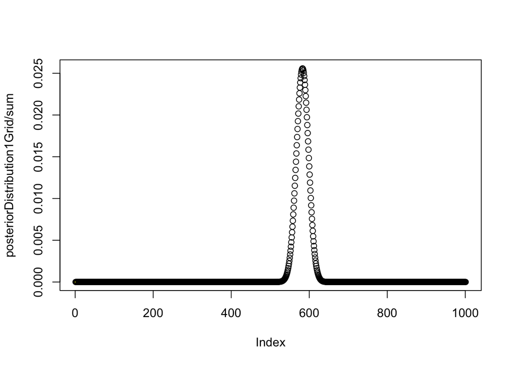

```r
#grid plot
plot(posteriorDistribution1Grid/sum)
my_gridHist1 = hist(posteriorDistribution1Grid, breaks=200, plot=FALSE)
lines(my_gridHist1$mids, dbeta(my_gridHist1$mids, 40+583, 40+417)/dbetasum, col="yellow")
```

###### Why does this plot look different than the plot in (1B)?

- The plots look different because there are more data points involved to improve accuracy.